# MNIST - A Study of ML Classification

### The MNIST dataset is a set of 70,000 small images of digits handwritten by high school students and employees of the US Census Bureau. It is a subset of a larger set available from NIST. The digits have been size-normalized and centered in a fixed-size image. Each image is labeled with the digit it represents. It is a perfect database for people who want to try learning techniques and pattern recognition methods on real-world data while spending minimal efforts on preprocessing and formatting. Whenever people come up with a new classification algorithm, they are curious to see how it will perform on MNIST. Whenever someone learns Machine Learning, sooner or later they tackle MNIST.

more about data set here: http://yann.lecun.com/exdb/mnist/

### First, import few common libraries, ensure matplotlib plots figures inline and prepare a function to save the figures:

```python
import numpy as np
import os

np.random.seed(42)

%matplotlib inline
import matplotlib
import matplotlib.pyplot as plt
plt.rcParams['axes.labelsize'] = 14
plt.rcParams['xtick.labelsize'] = 12
plt.rcParams['ytick.labelsize'] = 12

PROJECT_ROOT_DIR = "."
CHAPTER_ID = "classification"

def save_fig(fig_id, tight_layout=True):
    path = os.path.join(PROJECT_ROOT_DIR, "images", CHAPTER_ID, fig_id + ".png")
    print("Saving figure", fig_id)
    if tight_layout:
        plt.tight_layout()
    plt.savefig(path, format='png', dpi=300)

import warnings
warnings.filterwarnings(action='ignore')
```

```python
from sklearn.datasets import fetch_mldata
mnist = fetch_mldata('MNIST original')
mnist
```

```
{'COL_NAMES': ['label', 'data'],
 'DESCR': 'mldata.org dataset: mnist-original',
 'data': array([[0, 0, 0, ..., 0, 0, 0],
        [0, 0, 0, ..., 0, 0, 0],
        [0, 0, 0, ..., 0, 0, 0],
        ...,
        [0, 0, 0, ..., 0, 0, 0],
        [0, 0, 0, ..., 0, 0, 0],
        [0, 0, 0, ..., 0, 0, 0]], dtype=uint8),
 'target': array([0., 0., 0., ..., 9., 9., 9.])}
```

```python
X, y = mnist["data"], mnist["target"]
```

```python
print("X shape:", X.shape)
print("y shape:", y.shape)
```

```
X shape: (70000, 784)
y shape: (70000,)
```

```
Saving figure random_digit
```

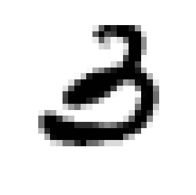

```python
%matplotlib inline
import matplotlib
import matplotlib.pyplot as plt

random_digit = X[24000]
random_digit_image = random_digit.reshape(28,28)
plt.imshow(random_digit_image, cmap = matplotlib.cm.binary,
          interpolation="nearest")
plt.axis("off")

save_fig("random_digit")
plt.show()
```

```python
def plot_digit(data):
    image = data.reshape(28, 28)
    plt.imshow(image, cmap = matplotlib.cm.binary,
               interpolation="nearest")
    plt.axis("off")
```

```python
def plot_digits(instances, images_per_row=5):
    size = 28
    images_per_row = min(len(instances), images_per_row)
    images = [instance.reshape(size,size) for instance in instances]
    n_rows = (len(instances) - 1) // images_per_row + 1
    row_images = []
    n_empty = n_rows * images_per_row - len(instances)
    images.append(np.zeros((size, size * n_empty)))
    for row in range(n_rows):
        rimages = images[row * images_per_row : (row + 1) * images_per_row]
        row_images.append(np.concatenate(rimages, axis=1))
    image = np.concatenate(row_images, axis=0)
    plt.imshow(image, cmap = matplotlib.cm.binary)
    plt.axis("off")
```

```
Saving figure more_digits_plot
```

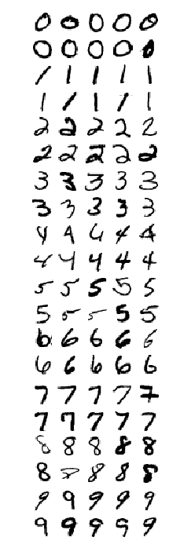

```python
plt.figure(figsize=(10,10))
example_images = np.r_[X[:12000:600], X[13000:30600:600], X[30600:60000:590]]
plot_digits(example_images, images_per_row=5)
save_fig("more_digits_plot")
plt.show()
```

```python
y[24000]
```

```
3.0
```

```python
X_train, X_test, y_train, y_test = X[:60000], X[60000:], y[:60000], y[60000:]
```

```python
shuffle_index = np.random.permutation(60000)
X_train, y_train = X_train[shuffle_index], y_train[shuffle_index]
```

### Training a Binary Classifier

To simplify the problem for now let's only try to identify one digit - the number 3. This "3-detector" will be an example of binary classifer, capable of distinguishing between just two classes, 3 and not 3.

```python
y_train_3 = (y_train == 3)
y_test_5 = (y_test == 3)
```

To pick a classifer, a good place to start is with Stochastic Gradient Descent(SGD) classifie, using Scikit-Learn's SGDClassifier class. This classifier has the capablity to handle large datasets efficently.

```python
from sklearn.linear_model import SGDClassifier

sgd_clf = SGDClassifier(random_state=42)
sgd_clf.fit(X_train, y_train_3)
```

```
SGDClassifier(alpha=0.0001, average=False, class_weight=None, epsilon=0.1,
       eta0=0.0, fit_intercept=True, l1_ratio=0.15,
       learning_rate='optimal', loss='hinge', max_iter=None, n_iter=None,
       n_jobs=1, penalty='l2', power_t=0.5, random_state=42, shuffle=True,
       tol=None, verbose=0, warm_start=False)
```

```python
sgd_clf.predict([random_digit])
```

```
array([ True])
```

### Performance Measures

Evaluating a classifier is significantly trickier than evaluating a regressor. There are many performance measures available.

#### Measuring Accuracy Using Cross-Validation

A good way to evaluate performace measure is to use cross-validation:

```python
from sklearn.model_selection import cross_val_score
cross_val_score(sgd_clf, X_train, y_train_3, cv=3, scoring="accuracy")
```

```
array([0.94815259, 0.96385   , 0.9340467 ])
```

That's right that's over 90% accuracy across all 3 folds. This is simply because only about 10% of the images are 3s, so if we always guess that an image is not a 3, we will be right about 90% of the time.

#### 1) Confusion Matrix

A much better way to evaluate the performance of a classifier is to look at the confusion matrix. The general is to count the number of times instances of class A are classified as class B. For eg, to know the number of times the classifier confused images of 3s with 6s, we would look in the 3rd row and 6th column of the confusion matrix. To compute the confusion matrix, we first need to have a set of predictions. We can get the predictions on the train set using cross_val_predict() function which return predictions for each instance in the training set.

```python
from sklearn.model_selection import cross_val_predict
y_train_pred = cross_val_predict(sgd_clf, X_train, y_train_3, cv=3)
```

```python
from sklearn.metrics import confusion_matrix
confusion_matrix(y_train_3, y_train_pred)
```

```
array([[51523,  2346],
       [  733,  5398]], dtype=int64)
```

#### 2) Precision and Recall

```python
from sklearn.metrics import precision_score, recall_score
precision_score(y_train_3, y_train_pred) # 5398 / (5398 + 2346)
```

```
0.6970557851239669
```

```python
recall_score(y_train_3, y_train_pred) # 5398 / (5498 +733)
```

```
0.8804436470396346
```

It is often convenient to combine precision and recall into single metric called the F1 score, in particular if we need a simple way to compare two classifier. The F1 score is the harmonic mean of precision and recall. Whereas the regular mean treats all values equally, the harmonic mean gives much more weight to low values. As a result, the classifier will get a high F1, score if both recall and precision are high.

```python
from sklearn.metrics import f1_score
f1_score(y_train_3, y_train_pred)
```

```
0.7780900900900901
```

#### 3) Precision/Recall Tradeoff

```python
y_scores = sgd_clf.decision_function([random_digit])
y_scores
```

```
array([18165.28807677])
```

```python
threshold = 0
y_random_digit_pred = (y_scores > threshold)
y_random_digit_pred
```

```
array([ True])
```

```python
threshold = 200000
y_random_digit_pred = (y_scores > threshold)
y_random_digit_pred
```

```
array([False])
```

```python
y_scores = cross_val_predict(sgd_clf, X_train, y_train_3, cv=3, method="decision_function")
```

```python
from sklearn.metrics import precision_recall_curve
precisions, recalls, thresholds = precision_recall_curve(y_train_3, y_scores)
```

```
Saving figure pression_recall_vs_threshold_plot
```

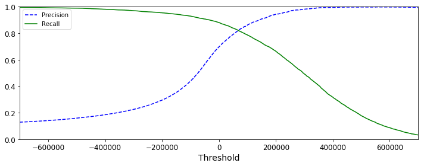

```python
def plot_precision_recall_vs_threshold(precisions, recalls, thresholds):
    plt.plot(thresholds, precisions[:-1], "b--", label="Precision")
    plt.plot(thresholds, recalls[:-1], "g-", label="Recall")
    plt.xlabel("Threshold")
    plt.legend(loc="upper left")
    plt.xlim([-700000, 700000])
    plt.ylim([0,1])

plt.figure(figsize=(10, 4))
plot_precision_recall_vs_threshold(precisions, recalls, thresholds)
save_fig("pression_recall_vs_threshold_plot")
plt.show()
```

```python
y_train_pred_90 = (y_scores > 70000)
```

```python
precision_score(y_train_3, y_train_pred_90)
```

```
0.823249713067716
```

```python
recall_score(y_train_3, y_train_pred_90)
```

```
0.8189528625020388
```

```
Saving figure precision_vs_recall_plot
```

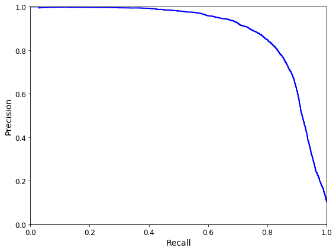

```python
def plot_precision_vs_recall(precisions, recalls):
    plt.plot(recalls, precisions, "b-", linewidth=2)
    plt.xlabel("Recall")
    plt.ylabel("Precision")
    plt.axis([0,1,0,1])
plt.figure(figsize=(8, 6))
plot_precision_vs_recall(precisions, recalls)
save_fig("precision_vs_recall_plot")
plt.show()
```

#### ROC curves

The receiver operating characteristic (ROC) curve is another common tool used with binary classifiers. It is very similar to the precision/recall curve, but instead of plotting precision versus recall, the ROC curve plots the true positive rate (another name for recall) against the false positive rate(FPR). The FPR is the ratio of negative instances that are incorrectly classified as positive. It is equal to one minus the true negative rate (TNR), which is the ratio of negative instances that are correctly classified as negative. The TNR is also called specificity.Hence the ROC curve plots sensitivity (recall) versus 1–specificity. To plot the ROC curve, we first need to compute the TPR and FPR for various threshold values, using the roc_curve() function:

```python
from sklearn.metrics import roc_curve
fpr, tpr, thresholds = roc_curve(y_train_3, y_scores)
```

```
Saving figure roc_curve_plot
```

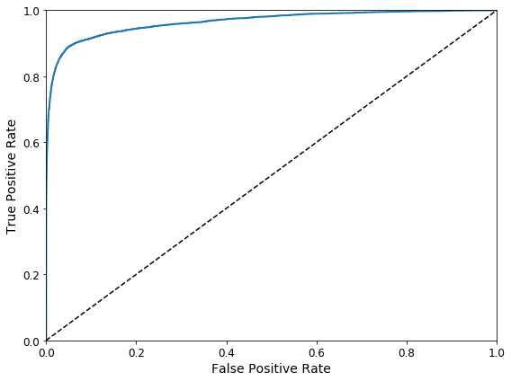

```python
def plot_roc_curve(fpr, tpr, label=None):
    plt.plot(fpr, tpr, linewidth=2, label=label)
    plt.plot([0,1],[0,1], 'k--')
    plt.axis([0,1,0,1])
    plt.xlabel('False Positive Rate')
    plt.ylabel('True Positive Rate')

plt.figure(figsize=(8,6))
plot_roc_curve(fpr,tpr)
save_fig("roc_curve_plot")
plt.show()
```

```python
from sklearn.metrics import roc_auc_score

roc_auc_score(y_train_3, y_scores)
```

```
0.9650257133358359
```

```python
from sklearn.ensemble import RandomForestClassifier
forest_clf = RandomForestClassifier(random_state=42)
y_probas_forest = cross_val_predict(forest_clf, X_train, y_train_3, cv=3,
                                    method="predict_proba")
```

```python
y_scores_forest = y_probas_forest[:, 1] # score = proba of positive class
fpr_forest, tpr_forest, thresholds_forest = roc_curve(y_train_3,y_scores_forest)
```

```
Saving figure roc_curve_comparison_plot
```

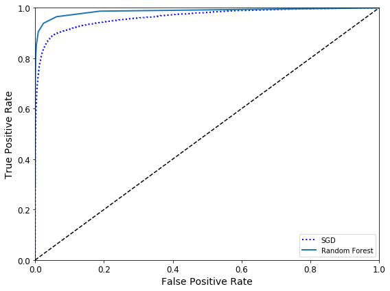

```python
plt.figure(figsize=(8, 6))
plt.plot(fpr, tpr, "b:", linewidth=2, label="SGD")
plot_roc_curve(fpr_forest, tpr_forest, "Random Forest")
plt.legend(loc="lower right")
save_fig("roc_curve_comparison_plot")
plt.show()
```

```python
roc_auc_score(y_train_3, y_scores_forest)
```

```
0.9871330465842308
```

```python
y_train_pred_forest = cross_val_predict(forest_clf, X_train, y_train_3, cv=3)
precision_score(y_train_3, y_train_pred_forest)
```

```
0.9854662898667743
```

```python
recall_score(y_train_3, y_train_pred_forest)
```

```
0.7962811939324743
```

### Multiclass Classification

Whereas binary classifiers distinguish between two classes, multiclass classifiers (also called multinomial classifiers) can distinguish between more than two classes.

```python
sgd_clf.fit(X_train, y_train)
sgd_clf.predict([random_digit])
```

```
array([3.])
```

```python
random_digit_scores = sgd_clf.decision_function([random_digit])
random_digit_scores
```

```
array([[ -499582.55705237,  -550812.09184579,  -735375.44069824,
           18165.28807677,  -816488.32333227,  -216282.22151398,
         -112654.73529414, -1426490.88561816, -1173446.3761975 ,
        -1126319.4885984 ]])
```

```python
np.argmax(random_digit_scores)
```

```
3
```

```python
sgd_clf.classes_
```

```
array([0., 1., 2., 3., 4., 5., 6., 7., 8., 9.])
```

```python
sgd_clf.classes_[3]
```

```
3.0
```

```python
from sklearn.multiclass import OneVsOneClassifier
ovo_clf = OneVsOneClassifier(SGDClassifier(max_iter=5, random_state=42))
ovo_clf.fit(X_train, y_train)
ovo_clf.predict([random_digit])
```

```
array([3.])
```

```python
len(ovo_clf.estimators_)
```

```
45
```

```python
forest_clf.fit(X_train, y_train)
forest_clf.predict([random_digit])
```

```
array([3.])
```

```python
forest_clf.predict_proba([random_digit])
```

```
array([[0. , 0. , 0. , 0.9, 0. , 0. , 0. , 0. , 0. , 0.1]])
```

```python
cross_val_score(sgd_clf, X_train, y_train, cv=3, scoring="accuracy")
```

```
array([0.84063187, 0.84899245, 0.86652998])
```

```python
from sklearn.preprocessing import StandardScaler
scaler = StandardScaler()
X_train_scaled = scaler.fit_transform(X_train.astype(np.float64))
cross_val_score(sgd_clf, X_train_scaled, y_train, cv=3, scoring="accuracy")
```

```
array([0.91011798, 0.90874544, 0.906636  ])
```

### Error Analysis

Here, we will assume that we have found a promising model and we want to find ways to improve it. One way to do this is to analyze the types of errors it makes.

```python
y_train_pred = cross_val_predict(sgd_clf, X_train_scaled, y_train, cv=3)
conf_mx = confusion_matrix(y_train, y_train_pred)
conf_mx
```

```
array([[5725,    3,   24,    9,   10,   49,   50,   10,   39,    4],
       [   2, 6493,   43,   25,    7,   40,    5,   10,  109,    8],
       [  51,   41, 5321,  104,   89,   26,   87,   60,  166,   13],
       [  47,   46,  141, 5342,    1,  231,   40,   50,  141,   92],
       [  19,   29,   41,   10, 5366,    9,   56,   37,   86,  189],
       [  73,   45,   36,  193,   64, 4582,  111,   30,  193,   94],
       [  29,   34,   44,    2,   42,   85, 5627,   10,   45,    0],
       [  25,   24,   74,   32,   54,   12,    6, 5787,   15,  236],
       [  52,  161,   73,  156,   10,  163,   61,   25, 5027,  123],
       [  43,   35,   26,   92,  178,   28,    2,  223,   82, 5240]],
      dtype=int64)
```

```python
"""To plot with color and a colorbar"""
def plot_confusion_matrix(matrix):
    fig = plt.figure(figsize=(8,8))
    ax = fig.add_subplot(111)
    cax = ax.matshow(matrix)
    fig.colorbar(cax)
```

```
Saving figure confusion_matrix_plot
```

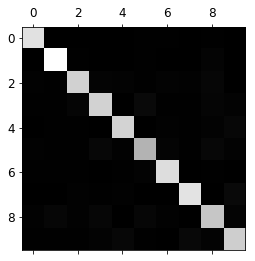

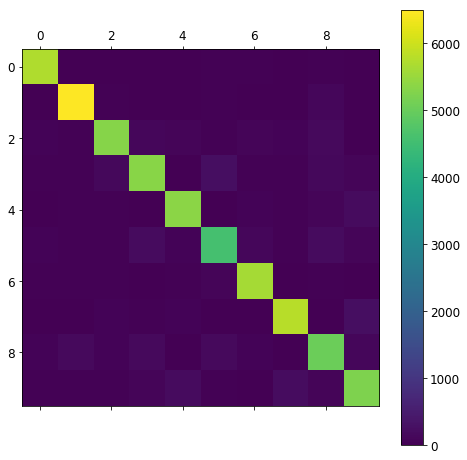

```python
plt.matshow(conf_mx, cmap=plt.cm.gray)
save_fig("confusion_matrix_plot", tight_layout=False)
plt.show()

plot_confusion_matrix(conf_mx)
```

```python
rows_sums = conf_mx.sum(axis=1, keepdims=True)
norm_conf_mx = conf_mx / rows_sums
```

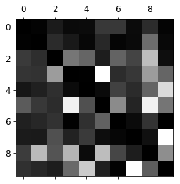

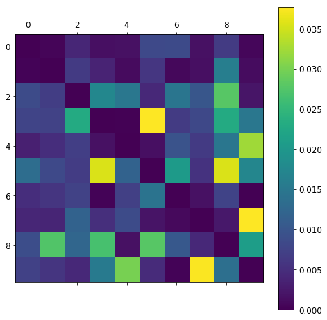

```python
np.fill_diagonal(norm_conf_mx, 0)
plt.matshow(norm_conf_mx, cmap=plt.cm.gray)
plt.show()

plot_confusion_matrix(norm_conf_mx)
```

```
Saving figure error_analysis_digits_plot
```

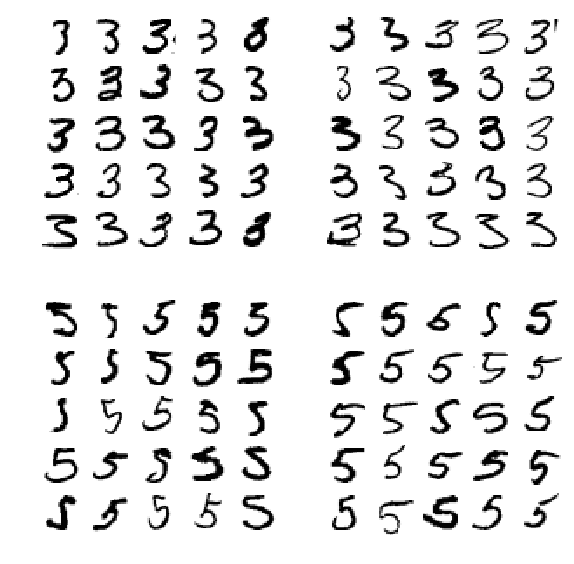

```python
cl_a, cl_b = 3, 5
X_aa = X_train[(y_train == cl_a) & (y_train_pred == cl_a)]
X_ab = X_train[(y_train == cl_a) & (y_train_pred == cl_b)]
X_ba = X_train[(y_train == cl_b) & (y_train_pred == cl_a)]
X_bb = X_train[(y_train == cl_b) & (y_train_pred == cl_b)]

plt.figure(figsize=(8,8))
plt.subplot(221); plot_digits(X_aa[:25], images_per_row=5)
plt.subplot(222); plot_digits(X_ab[:25], images_per_row=5)
plt.subplot(223); plot_digits(X_ba[:25], images_per_row=5)
plt.subplot(224); plot_digits(X_bb[:25], images_per_row=5)
save_fig("error_analysis_digits_plot")
plt.show()
```

### Multilabel Classification

In some cases we may want our classifier to output multiple classes for each instance. For example, consider a face-recognition classifier: what should it do if it recognizes several people on the same picture? This code creates a y_multilabel array containing two target labels for each digit image: the first indicates whether or not the digit is large (7, 8, or 9) and the second indicates whether or not it is odd.

```python
from sklearn.neighbors import KNeighborsClassifier

y_train_large = (y_train >= 7)
y_train_odd = (y_train % 2 == 1)
y_multilabel = np.c_[y_train_large, y_train_odd]

knn_clf = KNeighborsClassifier()
knn_clf.fit(X_train, y_multilabel)
```

```
KNeighborsClassifier(algorithm='auto', leaf_size=30, metric='minkowski',
           metric_params=None, n_jobs=1, n_neighbors=5, p=2,
           weights='uniform')
```

```python
knn_clf.predict([random_digit])
```

```
array([[False,  True]])
```

### Multioutput Classification

Multioutput Classification is simply a generalization of multilabel classification where each label can be multiclass (i.e., it can have more than two possible values). Let’s build a system that removes noise from images. It will take as input a noisy digit image, and it will (hopefully) output a clean digit image, represented as an array of pixel intensities, just like the MNIST images.

```python
noise = np.random.randint(0, 100, (len(X_train), 784))
X_train_mod = X_train + noise
noise = np.random.randint(0, 100, (len(X_test), 784))
X_test_mod = X_test + noise
y_train_mod = X_train
y_test_mod = X_test
```

```
Saving figure noisy_digit_example_plot
```

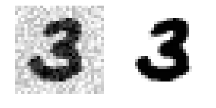

```python
random_index = 3500
plt.subplot(121); plot_digit(X_test_mod[random_index])
plt.subplot(122); plot_digit(y_test_mod[random_index])
save_fig("noisy_digit_example_plot")
plt.show()
```

On the left is the noisy input image, and on the right is the clean target image. Now let’s train the classifier and make it clean this image:

```
Saving figure cleaned_digit_example_plot
```

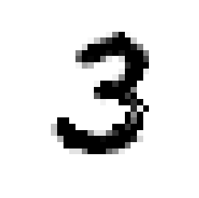

```python
knn_clf.fit(X_train_mod, y_train_mod)
clean_digit = knn_clf.predict([X_test_mod[random_index]])
plot_digit(clean_digit)
save_fig("cleaned_digit_example_plot")
```

The above image looks close enough to the target!

### Follow me on:

Github- https://github.com/jaynilpatel  
LinkedIn- https://www.linkedin.com/in/jaynil-patel-48b43212b/